# Обобщенные линейные модели с Пуассоновским распределением остатков

Линейные модели…

Наталья Арбузова, Вадим Хайтов, Валентина Домашкина, Анастасия Лянгузова, Юта Тамберг, Марина Варфоломеева

Кафедра Зоологии беспозвоночных, СПбГУ

## Мы рассмотрим

- Варианты анализа для случаев, когда зависимая перменная — счетная величина (целые неотрицательные числа)

### Вы сможете

- Объяснить особенности разных типов распределений, принадлежащих экспоненциальному семейству.
- Построить пуасоновскую и квази-пуассоновскую линейную модель
- Объяснить проблемы, связанные с избыточностью дисперсии в модели
- Построить модель, основанную на отрицательном биномиальном распределении

## Распределение Пуассона

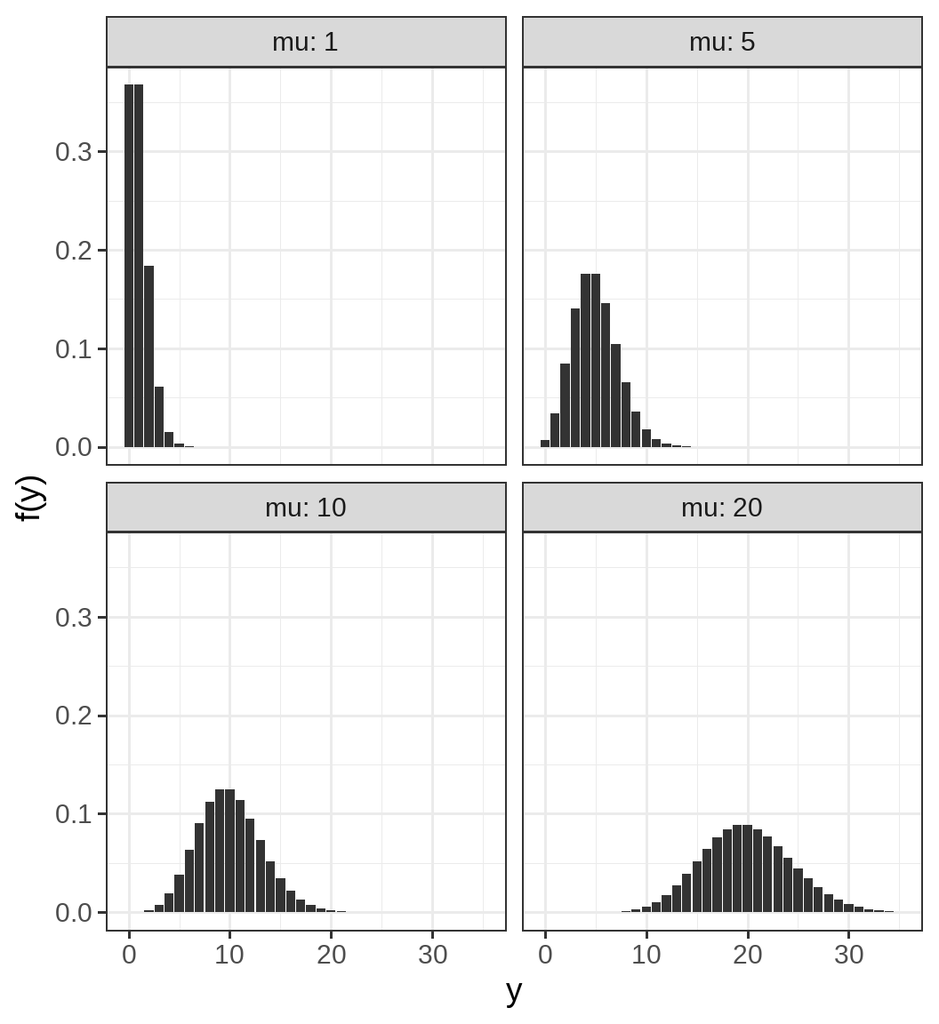

$$f(y)= \frac{\mu^y \cdot e^{-\mu}}{y!}$$

Параметр:

- $\mu$ – задает среднее и дисперсию

Свойства:

- $E(y) = \mu$ — мат.ожидание
- $var(y) = \mu$ — дисперсия
- $0 \le y \le +\infty$, $y \in \mathbb{N}$ — значения

## Отрицательное биномиальное распределение

[figure not shown]

$f(y) = \frac{\Gamma(y + k)}{\Gamma(k) \cdot \Gamma(y+1)} \cdot (\frac{k}{\mu + k})^k \cdot (1 - \frac{k}{\mu + k})^y$

Параметры:

- $\mu$ – среднее
- $k$ – определяет степень избыточности дисперсии

Свойства:

- $E(y) = \mu$ – мат.ожидание
- $var(y) = \mu + \frac {\mu^2}{k}$ – дисперсия
- $0 \le y \le +\infty$, $y \in \mathbb{N}$ – значения
- **О названии:** *NB* моделирует количество испытаний, необходимых для достижения определенного числа успехов, то есть *NB* моделирует количество неудач (поэтому и *“отрицательное”*).
- Это смесь Пуассоновского и Гамма распределений: $y$ подчиняется распределению Пуассона с Гамма-распределенным $\mu$. Приближается к распр. Пуассона при очень больших $k$.

## GLM в “туннеле” из распределений

В каждом конкретном случае при анализе данных нам предстоит выяснить, какое из распределений больше подходит для моделирования отклика.

- Достаточно ли возможностей распределения Пуассона, чтобы описать связь среднего и дисперсии?
- Если нет, то справится ли отрицательное биномиальное распределениие, у которого есть параметр, для описания этой связи?

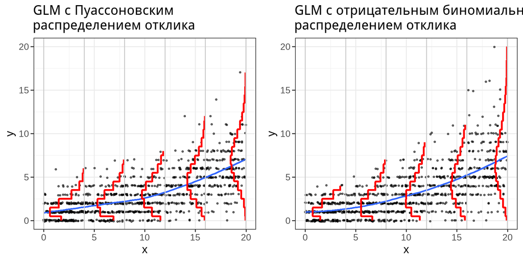

# Пример: визиты опылителей

## Мускари, копеечник и визиты опылителей

Мускари (*Leopoldia comosa*) — представитель родной флоры острова Менорка. В 18-19вв на остров завезли копеечник венечный (*Hedysarum coronarium*), который быстро натурализовался. Оба вида цветут одновременно и опыляются насекомыми.

Как зависит число визитов опылителей на цветки мускари от присутствия вселенца и разнообразия флоры в ближайшей окрестности? (Данные Montero-Castaño, Vilà, 2015)

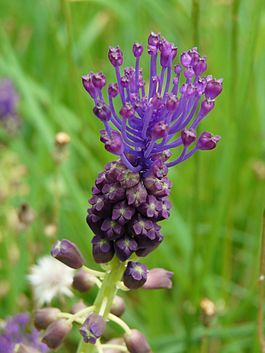

Muscari à toupet (Muscari comosum),  
Dordogne, France — Père Igor

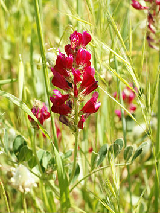

French-honeysuckle.  
Close to Santadi Basso, Sardinia, Italy  
— Hans Hillewaert

## Дизайн исследования

Подсчитывали число визитов опылителей на выбранное растение мускари  
(в пунктирной рамке) на трех типах участков.

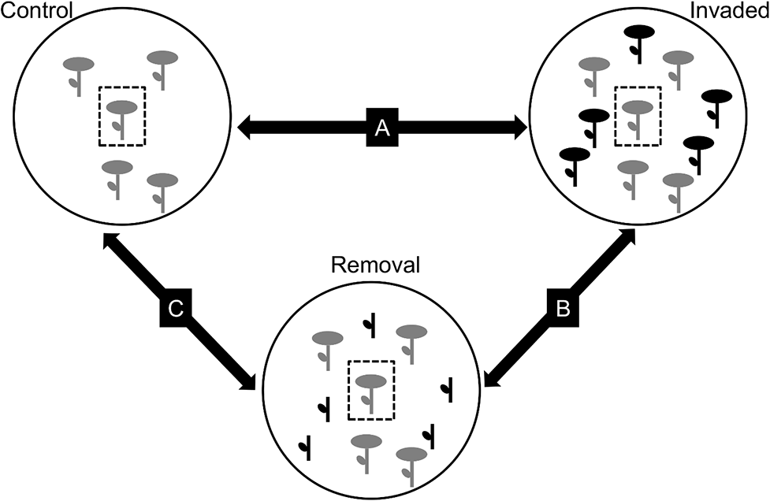

Fig.2 из [Montero-Castaño, Vilà, 2015](https://doi.org/10.1371/journal.pone.0128595)

## Переменные

Отклик и главный предиктор:

- `Visits` — число визитов всех опылителей на цветок мускари
- `Treatment` — тип площадки, тритмент (фактор с 3 уровнями):
  - `Invaded` — мускари в смеси с видом-вселенцем;
  - `Removal` — мускари в смеси с видом-вселенцем с удаленными цветками;
  - `Control` — мускари без вида-вселенца.

Важные ковариаты:

- `DiversityD_1` — Разнообразие флоры на площадке ( $exp(H’)$, где $H'$ — индекс Шеннона-Уивера) (возможно, на луг с более разнообразной растительностью прилетит больше опылителей).
- `Flowers` — число цветков мускари на площадке (чем больше, тем больше опылителей).
- `Hours` — продолжительность наблюдений (чем дольше, тем больше насчитали).

Другие переменные:

- `Total_1` — общая плотность цветков
- `Visits_NO_Apis` — посещения опылителей без учета пчел
- `Fruit` — число цветов с плодами через месяц
- `No_Fruit` — число цветов без плодов через месяц

## Открываем из знакомимся с данными

```r
library(readxl)
pol <- read_excel("data/Pollinators_Montero-Castano, Vila, 2015.xlsx",
                  sheet = 1)
head(pol)
```

```
# A tibble: 6 × 10
  Individual Treatment DiversityD_1 Visits Visits_NO_Apis Total_1 Fruit No_Fruit
       <dbl> <chr>            <dbl>  <dbl>          <dbl>   <dbl> <dbl>    <dbl>
1          1 Removal           2.66      4              4   53.9      0       10
2          2 Removal           1         6              6    2.45     2        7
3          3 Removal           1.44      5              5   41.6      5       14
4          4 Removal           2.21      1              1   58.8      6        9
5          5 Removal           2.83      6              6   19.6      3       13
6          6 Removal           2.40      2              2   78.4      1       21
# ℹ 2 more variables: Flowers <dbl>, Hours <dbl>
```

```r
# Сколько пропущенных значений?
colSums(is.na(pol))
```

```
    Individual      Treatment   DiversityD_1         Visits Visits_NO_Apis
             0              0              0              0              0
       Total_1          Fruit       No_Fruit        Flowers          Hours
             0              0              0              0              0
```

## Есть ли выбросы?

```r
library(ggplot2)
theme_set(theme_bw())
```

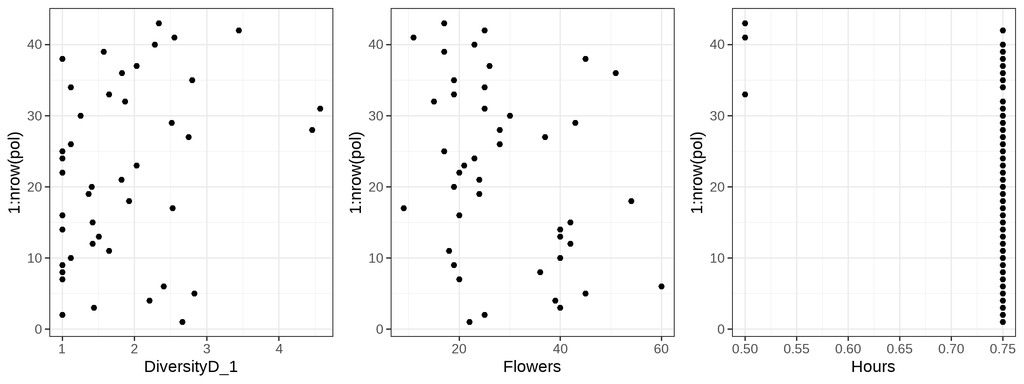

```r
library(cowplot)
dot_plot <- ggplot(pol, aes(y = 1:nrow(pol))) + geom_point()
plot_grid(dot_plot + aes(x = DiversityD_1),
          dot_plot + aes(x = Flowers),
          dot_plot + aes(x = Hours), nrow = 1)
```

- Выбросов нет.
- Разную продолжительность периодов наблюдений нужно учесть в модели.

## Каков объем выборки?

```r
table(pol$Treatment)
```

```
Control Invaded Removal
     14      11      18
```

### Как распределены короткие периоды наблюдений по тритментам?

```r
table(pol$Hours, pol$Treatment)
```

```
       Control Invaded Removal
  0.5        2       1       0
  0.75      12      10      18
```

## Коллинеарны ли непрерывные и дискретные предикторы?

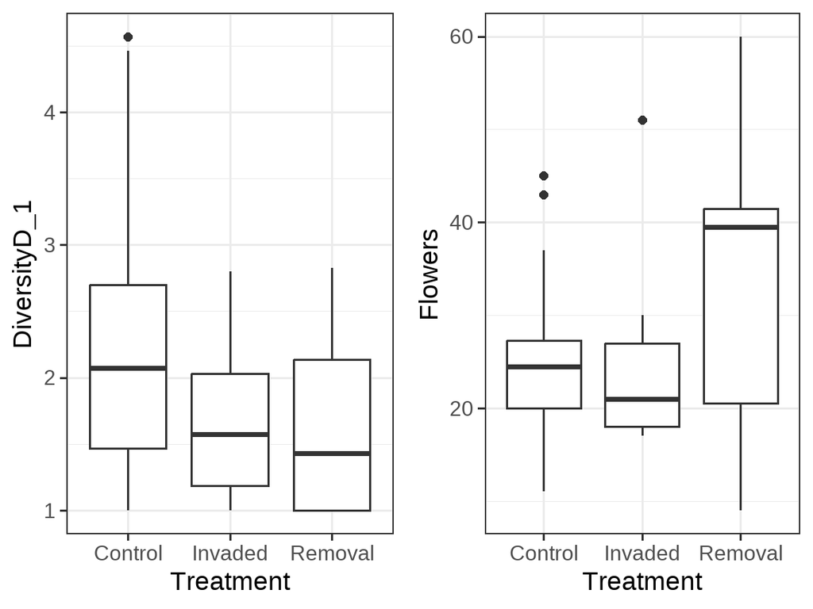

```r
box_plot <- ggplot(pol, aes(x = Treatment)) + geom_boxplot()

plot_grid(box_plot + aes(y = DiversityD_1),
          box_plot + aes(y = Flowers), nrow = 1)
```

- Возможно, есть коллинеарность.  
  Перед подбором модели проверим это при помощи `vif()`

## Как распределена переменная-отклик?

Число визитов насекомых – счетная переменная. Для ее моделирования нужно использовать подходящее распределение.

```r
ggplot(pol, aes(x = Visits)) + geom_histogram()
```

```r
mean(pol$Visits == 0) # Какова пропорция нулей?
```

```
[1] 0.2093
```

[figure not shown]

- Примерно 21% наблюдений – нули. Иногда из-за избытка нулей (Zero inflation) в модели может появиться избыточность дисперсии. Будем иметь это в виду.

# GLM с нормальным распределением отклика

## Что будет, если проигнорировать, что отклик — численная переменная?

$Visits_i \sim N(\mu_i, \sigma)$

$E(Visits_i) = \mu_i$, $var(Visits_i) = \sigma^2$

$\mu_i = \eta_i$ – функция связи “идентичность”

$\eta_i = b_0 + b_1 Treatment_{Invaded\ i} + b_2 Treatment_{Removal\ i} + \\ + b_3 DiversityD1_{i} + b_4 Flowers_{i} + b_5 Hours_{i}$

```r
M_norm <- glm(Visits ~ Treatment + DiversityD_1 + Flowers + Hours, data = pol)
coef(M_norm)
```

```
     (Intercept) TreatmentInvaded TreatmentRemoval
         -3.2545           2.8908          -1.0617
    DiversityD_1          Flowers            Hours
         -1.2041           0.1439           6.6546
```

```r
sigma(M_norm)
```

```
[1] 4.174
```

$Visits_i \sim N(\mu_i, 4.17)$  
$E(Visits_i) = \mu_i$, $var(Visits_i) = \sigma^2$  
$\mu_i = \eta_i$ $\eta_i = -3.3 + 2.9 Treatment_{Invaded\ i} -1.1 Treatment_{Removal\ i} - \\ -1.2 DiversityD1_{i} + 0.1 Flowers_{i} + 6.7 Hours_{i}$

## Данные для графика предсказаний простой линейной модели

```r
library(dplyr)
NewData <- pol %>%
  group_by(Treatment)%>%
  do(data.frame(Flowers = seq(min(.$Flowers), max(.$Flowers), length.out=50))) %>%
  mutate(DiversityD_1 = mean(pol$DiversityD_1),
         Hours = 0.75)

# Модельная матрица и коэффициенты
X <- model.matrix(~ Treatment + DiversityD_1 + Flowers + Hours, data = NewData)
betas <- coef(M_norm)
# Предсказания в масштабе функции связи (eta) уже в масштабе отклика (mu)
NewData$mu <- X %*% betas
NewData$SE_mu <- sqrt(diag(X %*% vcov(M_norm) %*% t(X)))  # SE

head(NewData, 3)
```

```
# A tibble: 3 × 6
# Groups:   Treatment [1]
  Treatment Flowers DiversityD_1 Hours mu[,1] SE_mu
  <chr>       <dbl>        <dbl> <dbl>  <dbl> <dbl>
1 Control      11           1.86  0.75   1.08  1.54
2 Control      11.7         1.86  0.75   1.18  1.52
3 Control      12.4         1.86  0.75   1.28  1.49
```

## График предсказаний

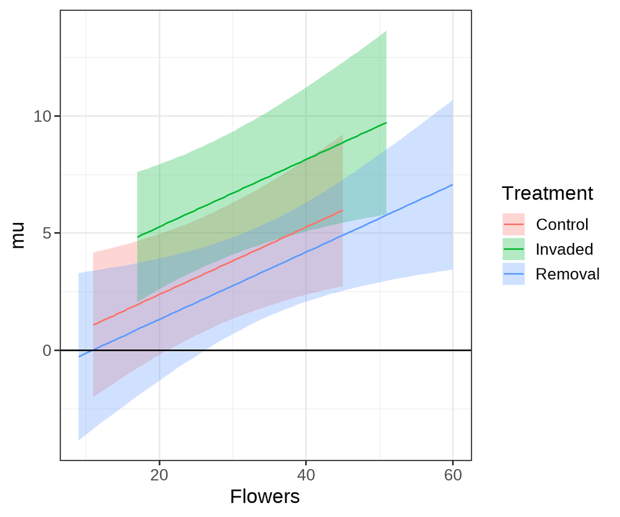

```r
ggplot(NewData, aes(x = Flowers, y = mu, fill = Treatment)) +
  geom_ribbon(aes(ymin = mu - 2 * SE_mu, ymax = mu + 2 * SE_mu), alpha=0.3)+
  geom_line(aes(colour = Treatment)) +
  geom_hline(yintercept = 0)
```

[figure not shown]

Отрицательные предсказания!

С такой моделью работать точно нельзя, но мы продолжим из любопытства. Нужно же посмотреть, какие еще проблемы возникают при использовании нормального распределения для моделирования счетных величнн.

## Результаты подбора модели

```r
summary(M_norm)
```

```
Call:
glm(formula = Visits ~ Treatment + DiversityD_1 + Flowers + Hours,
    data = pol)

Coefficients:
                 Estimate Std. Error t value Pr(>|t|)
(Intercept)       -3.2545     7.7310   -0.42    0.676
TreatmentInvaded   2.8908     1.7626    1.64    0.109
TreatmentRemoval  -1.0617     1.6776   -0.63    0.531
DiversityD_1      -1.2041     0.7851   -1.53    0.134
Flowers            0.1439     0.0585    2.46    0.019 *
Hours              6.6546    10.6424    0.63    0.536
---
Signif. codes:  0 '***' 0.001 '**' 0.01 '*' 0.05 '.' 0.1 ' ' 1

(Dispersion parameter for gaussian family taken to be 17.42)

    Null deviance: 891.86  on 42  degrees of freedom
Residual deviance: 644.61  on 37  degrees of freedom
AIC: 252.4

Number of Fisher Scoring iterations: 2
```

## Анализ девиансы для модели с нормальным распределением отклика

```r
drop1(M_norm, test = 'Chi')
```

```
Single term deletions

Model:
Visits ~ Treatment + DiversityD_1 + Flowers + Hours
             Df Deviance AIC scaled dev. Pr(>Chi)
<none>               645 252
Treatment     2      744 255        6.17    0.046 *
DiversityD_1  1      686 253        2.65    0.104
Flowers       1      750 257        6.51    0.011 *
Hours         1      651 251        0.45    0.501
---
Signif. codes:  0 '***' 0.001 '**' 0.01 '*' 0.05 '.' 0.1 ' ' 1
```

Прежде чем доверять этим результатам, нужно проверить, выполняются ли условия применимости.

## Нет ли коллинеарности предикторов

```r
library(car)
vif(M_norm)
```

```
              GVIF Df GVIF^(1/(2*Df))
Treatment    1.357  2           1.079
DiversityD_1 1.162  1           1.078
Flowers      1.226  1           1.107
Hours        1.134  1           1.065
```

- Коллинеарности нет.

## Задание 1

Постройте график пирсоновских остатков от предсказанных значений для модели `M_norm`.

Какие нарушения условий применимости вы на нем видите?

Дополните код:

```r
M_norm_diag <- data.frame(.fitted = fitted(),
                          .resid_p = residuals())

ggplot(data = , aes()) + geom_hline( = 0) +
  geom_point()
```

## График остатков от предсказанных значений

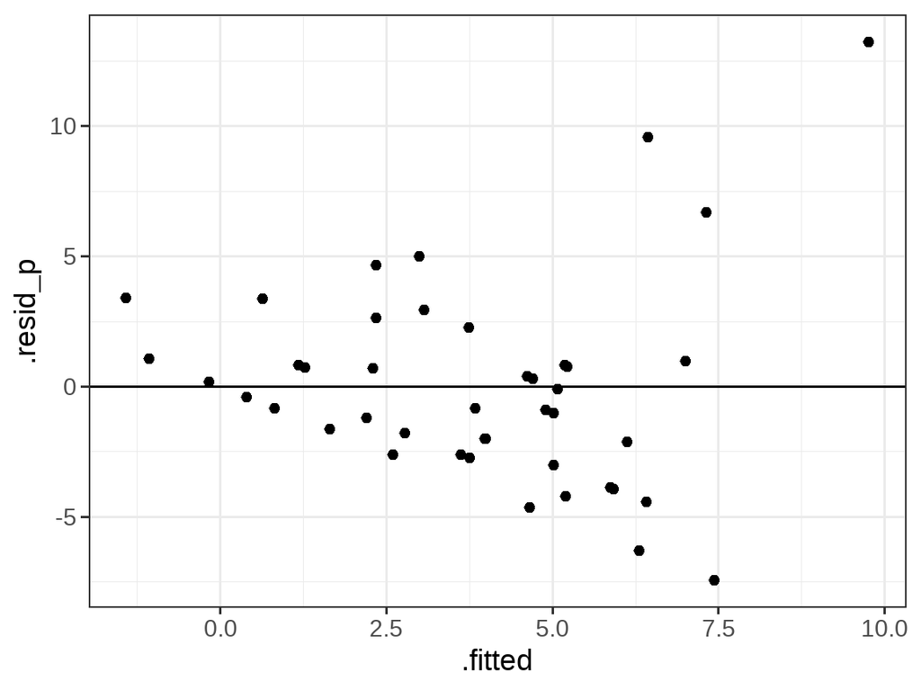

```r
M_norm_diag <- data.frame(.fitted = fitted(M_norm, type = "response"),
                          .resid_p = residuals(M_norm, type = "pearson"))

ggplot(M_norm_diag, aes(y = .resid_p)) + geom_hline(yintercept = 0) +
  geom_point(aes(x = .fitted))
```

[figure not shown]

- Гетерогенность дисперсий остатков.
- Отрицательные предсказания!

Чуда не произошло

## Модель с нормальным распределением отклика не подходит

Два способа решения проблем с моделью:

1. Грубый способ: логарифмировать зависимую переменную и построить модель для нее.
2. Лучше построить модель, основанную на распределении, подходящем для счетных данных:
   - распределение Пуассона,
   - отрицательное биномиальное распределение.

# GLM с Пуассоновским распределением отклика

## GLM с Пуассоновским распределением отклика

$Visits_i \sim Poisson(\mu_i)$

$E(Visits_i) = \mu_i$, $var(Visits_i) = \mu_i$

$\text{ln}(\mu_i) = \eta_i$ — функция связи логарифм

$\begin{aligned}\eta_i & = b_0 + b_1 Treatment_{Invaded\ i} + b_2 Treatment_{Removal\ i} + \\ &+ b_3 DiversityD1_{i} + b_4 Flowers_{i} + b_5 Hours_{i}\end{aligned}$

```r
M_pois <- glm(Visits ~ Treatment + DiversityD_1 + Flowers + Hours,
              data = pol, family = "poisson")
coef(M_pois)
```

```
     (Intercept) TreatmentInvaded TreatmentRemoval
        -2.66091          0.71342         -0.21538
    DiversityD_1          Flowers            Hours
        -0.45740          0.03731          4.68669
```

$Visits_i \sim Poisson(\mu_i)$  
$E(Visits_i) = \mu_i$, $var(Visits_i) = \mu_i$  
$\text{ln}(\mu_i) = \eta_i$  
$\begin{aligned}\eta_i = &-2.66 + 0.71 Treatment_{Invaded\ i} - 0.22 Treatment_{Removal\ i} - \\ &- 0.46 DiversityD1_i + 0.04 Flowers_i + 4.69 Hours_i\end{aligned}$

## Тесты коэффициентов Пуассоновской GLM

Для тестирования значимости коэффициентов в Пуассоновской GLM используются  
**z-тесты Вальда**, т.к. не приходится оценивать дисперсию и  
t-статистика Вальда будет подчиняться нормальному распределению.

```r
summary(M_pois)
```

```
Call:
glm(formula = Visits ~ Treatment + DiversityD_1 + Flowers + Hours,
    family = "poisson", data = pol)

Coefficients:
                 Estimate Std. Error z value    Pr(>|z|)
(Intercept)      -2.66091    2.17444   -1.22     0.22106
TreatmentInvaded  0.71342    0.21416    3.33     0.00086 ***
TreatmentRemoval -0.21538    0.22265   -0.97     0.33337
DiversityD_1     -0.45740    0.12859   -3.56     0.00037 ***
Flowers           0.03731    0.00683    5.46 0.000000048 ***
Hours             4.68669    2.90325    1.61     0.10646
---
Signif. codes:  0 '***' 0.001 '**' 0.01 '*' 0.05 '.' 0.1 ' ' 1

(Dispersion parameter for poisson family taken to be 1)

    Null deviance: 189.75  on 42  degrees of freedom
Residual deviance: 119.88  on 37  degrees of freedom
AIC: 238.8

Number of Fisher Scoring iterations: 6
```

## Смысл коэффициентов Пуассоновской GLM

**Интерсепт** $b_0$ показывает чему равно значение $\eta = ln(\mu_i)$ на базовом уровне, когда все предикторы $x_k = 0$.  
Значит, значение самого отклика равно $e^{b_0}$.

Т.е. если разнообразие цветов DiversityD_1, обилие цветов Flowers и время наблюдения Hours равны нулю, то ожидаемое число визитов опылителей $e^{-2.661} = 0.07$.

Для этих данных $b_0$ не имеет биологического смысла.

```r
summary(M_pois)
```

```
Call:
glm(formula = Visits ~ Treatment + DiversityD_1 + Flowers + Hours,
    family = "poisson", data = pol)

Coefficients:
                 Estimate Std. Error z value    Pr(>|z|)
(Intercept)      -2.66091    2.17444   -1.22     0.22106
TreatmentInvaded  0.71342    0.21416    3.33     0.00086 ***
TreatmentRemoval -0.21538    0.22265   -0.97     0.33337
DiversityD_1     -0.45740    0.12859   -3.56     0.00037 ***
Flowers           0.03731    0.00683    5.46 0.000000048 ***
Hours             4.68669    2.90325    1.61     0.10646
---
Signif. codes:  0 '***' 0.001 '**' 0.01 '*' 0.05 '.' 0.1 ' ' 1

(Dispersion parameter for poisson family taken to be 1)

    Null deviance: 189.75  on 42  degrees of freedom
Residual deviance: 119.88  on 37  degrees of freedom
AIC: 238.8

Number of Fisher Scoring iterations: 6
```

## Смысл коэффициентов Пуассоновской GLM

Коэффициенты $b_k$ при переменных-индикаторах $x_k$, кодирующих уровни **дискретных предикторов**, показывают, на сколько единиц отличается значение $\eta = ln(\mu_i)$ от базового уровня.  
Значит, значение отклика отличается в $e^{b_k}$ раз от базового уровня.

Т.е. в присутствии вида-вселенца в $e^{0.713} = 2.04$ раза больше визитов опылителей, а при удалении - в $e^{-0.215} = 0.81$ раза, т.е. на 19% меньше чем в контроле.

```r
summary(M_pois)
```

```
Call:
glm(formula = Visits ~ Treatment + DiversityD_1 + Flowers + Hours,
    family = "poisson", data = pol)

Coefficients:
                 Estimate Std. Error z value    Pr(>|z|)
(Intercept)      -2.66091    2.17444   -1.22     0.22106
TreatmentInvaded  0.71342    0.21416    3.33     0.00086 ***
TreatmentRemoval -0.21538    0.22265   -0.97     0.33337
DiversityD_1     -0.45740    0.12859   -3.56     0.00037 ***
Flowers           0.03731    0.00683    5.46 0.000000048 ***
Hours             4.68669    2.90325    1.61     0.10646
---
Signif. codes:  0 '***' 0.001 '**' 0.01 '*' 0.05 '.' 0.1 ' ' 1

(Dispersion parameter for poisson family taken to be 1)

    Null deviance: 189.75  on 42  degrees of freedom
Residual deviance: 119.88  on 37  degrees of freedom
AIC: 238.8

Number of Fisher Scoring iterations: 6
```

## Смысл коэффициентов Пуассоновской GLM

Угловые коэффициенты при **непрерывных предикторах** $b_k$ показывают, на сколько единиц меняется значение $\eta = ln(\mu_i)$, если предиктор $x_k$ изменяется на единицу.  
Значит, сам отклик изменяется в $e^{b_k}$ раз.

Т.е. при росте биоразнообразия на 1 число визитов изменяется в $e^{-0.457} = 0.63$ раз, т.е. уменьшается на 37%.

А если цветков мускари больше на 1, то растет в $e^{0.037} = 1.04$ раз, т.е. на 4%.

```r
summary(M_pois)
```

```
Call:
glm(formula = Visits ~ Treatment + DiversityD_1 + Flowers + Hours,
    family = "poisson", data = pol)

Coefficients:
                 Estimate Std. Error z value    Pr(>|z|)
(Intercept)      -2.66091    2.17444   -1.22     0.22106
TreatmentInvaded  0.71342    0.21416    3.33     0.00086 ***
TreatmentRemoval -0.21538    0.22265   -0.97     0.33337
DiversityD_1     -0.45740    0.12859   -3.56     0.00037 ***
Flowers           0.03731    0.00683    5.46 0.000000048 ***
Hours             4.68669    2.90325    1.61     0.10646
---
Signif. codes:  0 '***' 0.001 '**' 0.01 '*' 0.05 '.' 0.1 ' ' 1

(Dispersion parameter for poisson family taken to be 1)

    Null deviance: 189.75  on 42  degrees of freedom
Residual deviance: 119.88  on 37  degrees of freedom
AIC: 238.8

Number of Fisher Scoring iterations: 6
```

## Анализ девиансы для модели с Пуассоновским распределением отклика

```r
drop1(M_pois, test = 'Chi')
```

```
Single term deletions

Model:
Visits ~ Treatment + DiversityD_1 + Flowers + Hours
             Df Deviance AIC   LRT    Pr(>Chi)
<none>               120 239
Treatment     2      145 260 25.41 0.000003037 ***
DiversityD_1  1      134 251 14.43     0.00015 ***
Flowers       1      149 266 28.79 0.000000081 ***
Hours         1      124 240  3.76     0.05261 .
---
Signif. codes:  0 '***' 0.001 '**' 0.01 '*' 0.05 '.' 0.1 ' ' 1
```

Число визитов опылителей на цветки мускари:

- зависит от присутствия вида-вселенца и его цветов,
- зависит от разнообразия флоры на данном участке,
- зависит от числа цветов самого мускари.

Можем ли мы доверять этим результатам? Пока не известно.

## Данные для предсказаний

```r
NewData <- pol %>%
  group_by(Treatment)%>%
  do(data.frame(Flowers = seq(min(.$Flowers), max(.$Flowers), length.out=50))) %>%
  mutate(DiversityD_1 = mean(pol$DiversityD_1),
         Hours = 0.75)
```

Давайте получим предсказания при помощи операций с матрицами,  
чтобы своими глазами увидеть работу функции связи.

Осторожно!  
Хоть и можно получить предсказания при помощи `predict()`, но  
**`predict()` возвращает “правильные” `SE` только в масштабе функции связи!**

```r
?predict.glm
```

## Задание 2

Дополните код, чтобы получить предсказания модели при помощи операций с матрицами.

```r
# Модельная матрица и коэффициенты
X <-
betas <-

# Предсказанные значения и стандартные ошибки...
# ...в масштабе функции связи (логарифм)
NewData$fit_eta <-
NewData$SE_eta <- sqrt(( %*% vcov(M_pois) %*% ))

# ...в масштабе отклика (применяем функцию, обратную функции связи)
NewData$fit_mu <-
NewData$lwr <-
NewData$upr <-
```

## Предсказания модели при помощи операций с матрицами

```r
# Модельная матрица и коэффициенты
X <- model.matrix(~ Treatment + DiversityD_1 + Flowers + Hours, data = NewData)
betas <- coef(M_pois)

# Предсказанные значения и стандартные ошибки...
# ...в масштабе функции связи (логарифм)
NewData$fit_eta <- X %*% betas
NewData$SE_eta <- sqrt(diag(X %*% vcov(M_pois) %*% t(X)))

# ...в масштабе отклика (применяем функцию, обратную функции связи)
NewData$fit_mu <- exp(NewData$fit_eta)
NewData$lwr <- exp(NewData$fit_eta - 2 * NewData$SE_eta)
NewData$upr <- exp(NewData$fit_eta + 2 * NewData$SE_eta)

head(NewData, 2)
```

```
# A tibble: 2 × 9
# Groups:   Treatment [1]
  Treatment Flowers DiversityD_1 Hours fit_eta[,1] SE_eta fit_mu[,1] lwr[,1] upr[,1]
  <chr>       <dbl>        <dbl> <dbl>       <dbl>  <dbl>      <dbl>   <dbl>   <dbl>
1 Control      11           1.86  0.75       0.415  0.224       1.51   0.968    2.37
2 Control      11.7         1.86  0.75       0.441  0.221       1.55   0.999    2.42
```

## График предсказаний в масштабе функции связи

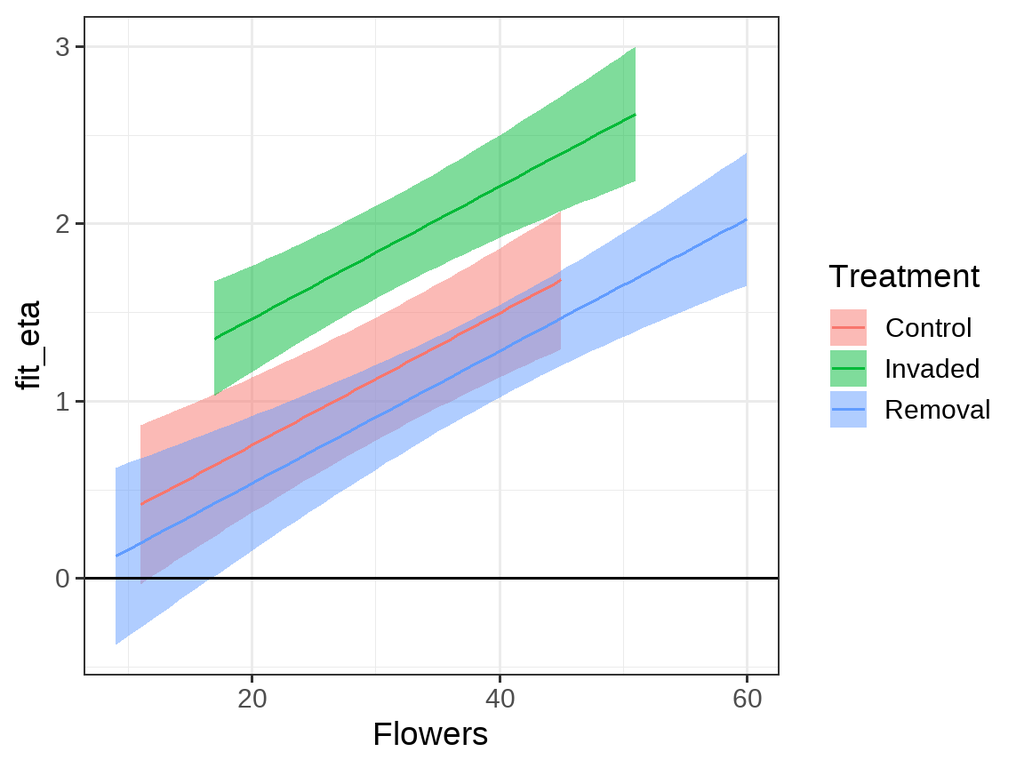

```r
ggplot(NewData, aes(x = Flowers, y = fit_eta, fill = Treatment)) +
  geom_ribbon(aes(ymin = fit_eta - 2 * SE_eta,
                  ymax = fit_eta + 2 * SE_eta),
              alpha = 0.5) +
  geom_line(aes(colour = Treatment)) +
  geom_hline(yintercept = 0)
```

В масштабе функции связи мы моделируем линейную зависимость логарифмов мат. ожидания отклика от предикторов.

## График предсказаний в масштабе переменной-отклика

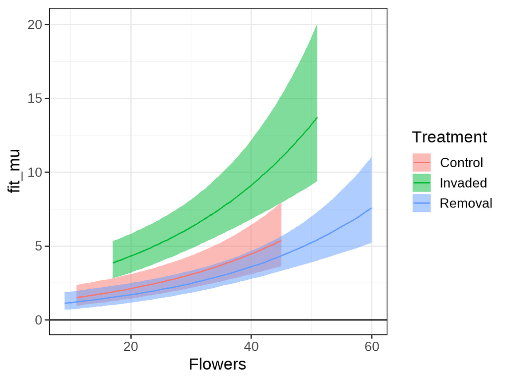

```r
ggplot(NewData, aes(x = Flowers, y = fit_mu, fill = Treatment)) +
  geom_ribbon(aes(ymin = lwr,
                  ymax = upr),
              alpha = 0.5) +
  geom_line(aes(colour = Treatment)) +
  geom_hline(yintercept = 0)
```

GLM с Пуассоновским распределением отклика моделирует его нелинейную cвязь предикторами за счет функции связи $log()$.

И никаких отрицательных предсказаний!

## Пуассоновские GLM: откуда ждать удар?

GLM с Пуассоновским распределением отклика учитывает гетерогенность дисперсии, т.к. $var(y_i) = mu_i = E(y_i)$. Стандартные ошибки возрастают с увеличением предсказанного значения.

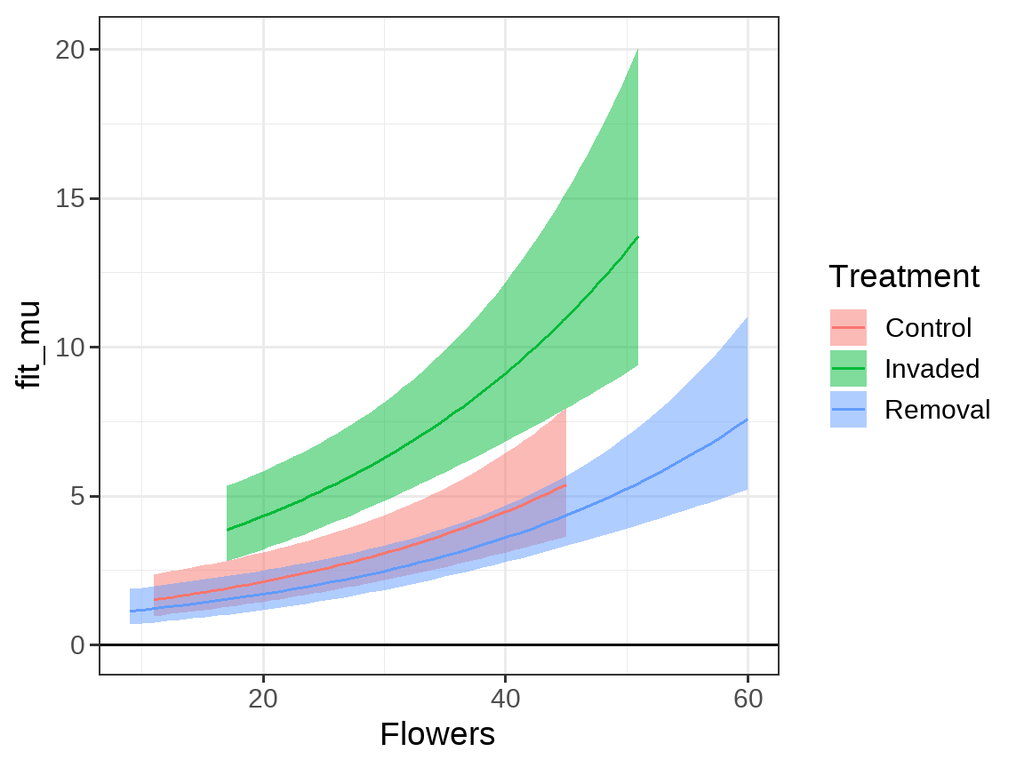

Но достаточно ли этого для моделирования данных? Нет ли здесь сверхдисперсии?

## Условия применимости GLM с Пуассоновским распределением отклика

- Случайность и независимость наблюдений внутри групп.
- Отсутствие сверхдисперсии. (Дисперсия остатков равна мат.ожиданию при каждом уровне значений предикторов).
- Отсутствие коллинеарности предикторов.
- Линейность связи.

## График остатков

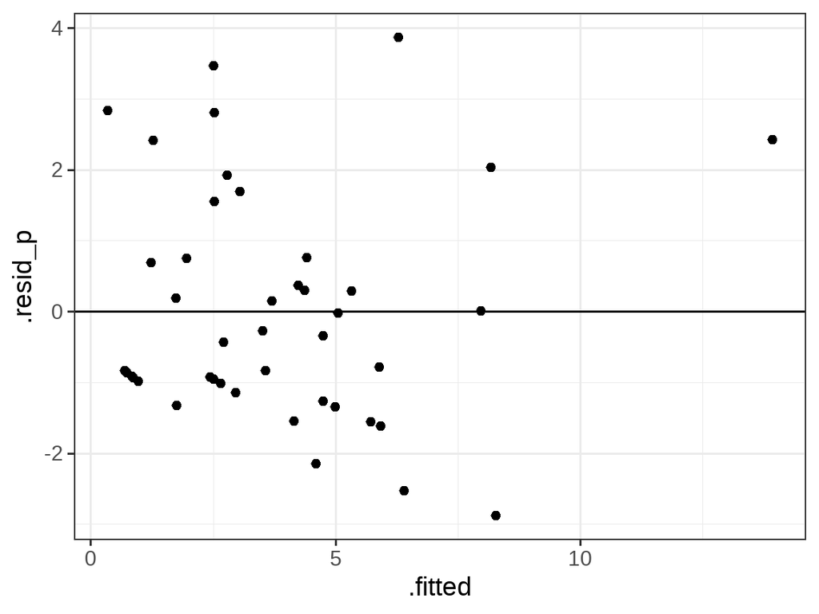

```r
M_pois_diag <- data.frame(.fitted = fitted(M_pois, type = "response"),
                            .resid_p = residuals(M_pois, type = "pearson"))
ggplot(M_pois_diag, aes(x = .fitted, y = .resid_p)) +
  geom_point() +
  geom_hline(yintercept = 0)
```

А что это за странные полоски?

Полоски из точек — это наблюдения с разными значениями отклика: 0, 1, 2, … визита опылителей.

Нет никаких отрицательных предсказаний!

# Избыточность дисперсии (overdispersion)

## Избыточность дисперсии (overdispersion)

Если данные подчиняются распределению Пуассона, то дисперсия должна быть равна среднему значению.

- $E(y_i) = \mu_i$
- $var(y_i) = \mu_i$

Если это не так, то мы не сможем доверять результатам. Это будет значить, что мы применяем модель, основанную на Пуассоновском распределении, к данным, которые не подчиняются этому распределению.

## Если есть избыточность дисперсии…

Пуассоновские модели недооценивают (приуменьшают) “раздувшиеся” стандартные ошибки.

**В норме, если данные подчиняются распределению Пуассона**, то:

$var(y_i) = \mu_i$

Т.е. дисперсии и стандартные ошибки, “нормальные” для распределения Пуассона:

$var(E(y_i)) = {\mu_i} / n$

$SE_{E(y_i)} = \sqrt {var(E(y_i))}$

**Если данные НЕ подчиняются распределению Пуассона**, и дисперсия в $\varphi$ раз больше среднего ( $\varphi > 1$), то:

$var^*(y_i) = \varphi\mu_i$

Тогда дисперсии должны быть больше в $\varphi$ раз, а стандартные ошибки — в $\sqrt {\varphi}$ раз:

$var^*(E(y_i)) = {\varphi\mu_i} / n$

$SE^*_{E(y_i)} = \sqrt {\varphi~var(E(y_i))}$

**Если при сверхдисперсии использовать обычное распределение Пуассона, то оценки стандартных ошибок окажутся занижены.**

## Проблемы из-за неучтенной избыточности дисперсии в Пуассоновских GLM

- Из-за того, что оценки стандартных ошибок занижены:
  - Доверительные интервалы для коэффициентов заужены
  - Доверительная зона предсказаний модели будет заужена
  - Уровень значимости в тестах Вальда для коэффициентов будет занижен.
- Повышается вероятность ошибок I рода!

## Проверка на сверхдисперсию

```r
# Функция для проверки наличия сверхдисперсии в модели (автор Ben Bolker)
# http://bbolker.github.io/mixedmodels-misc/glmmFAQ.html
# Код модифицирован, чтобы учесть дополнительный параметр в NegBin GLMM,
# подобранных MASS::glm.nb()
overdisp_fun <- function(model) {
  rdf <- df.residual(model)  # Число степеней свободы N - p
  if (any(class(model) == 'negbin')) rdf <- rdf - 1 ## учитываем k в NegBin GLMM
  rp <- residuals(model,type='pearson') # Пирсоновские остатки
  Pearson.chisq <- sum(rp^2) # Сумма квадратов остатков, подчиняется Хи-квадрат распределению
  prat <- Pearson.chisq/rdf  # Отношение суммы квадратов остатков к числу степеней свободы
  pval <- pchisq(Pearson.chisq, df=rdf, lower.tail=FALSE) # Уровень значимости
  c(chisq=Pearson.chisq,ratio=prat,rdf=rdf,p=pval)        # Вывод результатов
}
```

Модифицировано по Ben Bolker’s [glmmFAQ](http://bbolker.github.io/mixedmodels-misc/glmmFAQ.html)

```r
overdisp_fun(M_pois)
```

```
    chisq     ratio       rdf         p
1.116e+02 3.016e+00 3.700e+01 2.079e-09
```

Избыточность дисперсии есть! Дисперсия в 3 раза выше среднего.

## Для любителей DHARMa

```r
library(DHARMa)
sim_res <- simulateResiduals(fittedModel = M_pois, plot = TRUE)

# Тест на дисперсию (по умолчанию двусторонний)
testDispersion(sim_res)
```

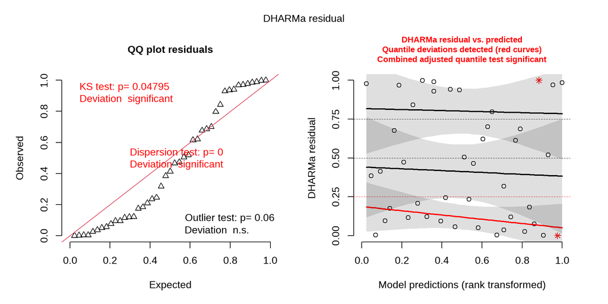

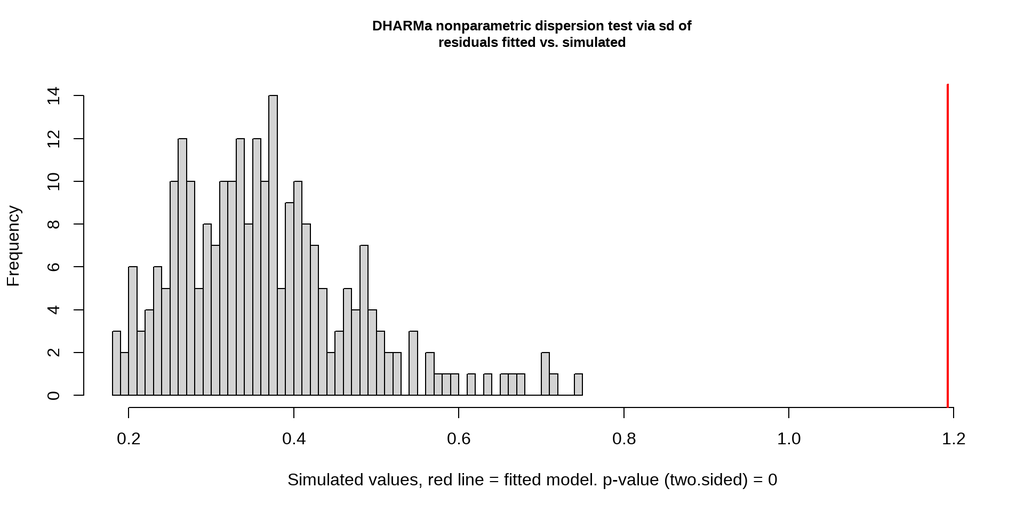

```
    DHARMa nonparametric dispersion test via sd of residuals fitted vs. simulated

data:  simulationOutput
dispersion = 3.3, p-value <2e-16
alternative hypothesis: two.sided
```

## Причины избыточности дисперсии

- Наличие выбросов.
- В модель не включен важный предиктор или взаимодействие предикторов.
- Нарушена независимость выборок (есть внутригрупповые корреляции).
- Нелинейная связь между ковариатами и зависимой переменной.
- Выбрана неподходящая связывающая функция.
- Количество нулей больше, чем предсказывает выбранное  
  распределение отклика (Zero inflation) .
- Выбрана неподходящая функция распределения для отклика.

### Как бороться с избыточностью дисперсии

Взвесив все, что известно о данных, можно решить, как именно усовершенствовать модель.

Для модели числа визитов опылителей мы попробуем два варианта действий:

- Можно построить квази-пуассоновскую модель.
- Можно построить модель, основанную на отрицательном биномиальном распределении.

# Квази-пуассоновские модели

## Квази-пуассоновские модели

Помните, не бывает  
“квази-пуассоновского  
распределения”!

[figure not shown]

$Visits_i \sim Quasipoisson(\mu_i)$

$E(Visits_i) = \mu_i$, $var(y_i) = \varphi\ \mu_i$

$\text{ln}(\mu_i) = \eta_i$ — функция связи логарифм

$\begin{aligned}\eta_i & = b_0 + b_1 Treatment_{Invaded\ i} + b_2 Treatment_{Removal\ i} + \\ &+ b_3 DiversityD1_{i} + b_4 Flowers_{i} + b_5 Hours_{i}\end{aligned}$

Квазипуассоновские модели используют распределение Пуассона, но при этом вносится поправка для стандартных ошибок на степень избыточности дисперсии $\varphi$.

$\varphi$ оценивается по данным и показывает, во сколько раз дисперсия больше среднего.

## Особенности квази-пуассоновской GLM

- Оценки параметров $\beta$ такие же как в Пуассоновской GLM.
- Стандартные ошибки оценок коэффициентов домножены на $\sqrt{\varphi}$.
- Доверительные интервалы к оценкам коэффициентов домножены на $\sqrt{\varphi}$.
- Логарифмы правдоподобий уменьшаются в $\varphi$ раз.

### Работа с квази-моделями

1. В тестах параметров используются $t$-тесты Вальда (и $t$-распределение) вместо $z$-тестов Вальда (и стандартного нормального распределения).
2. Для анализа девиансы используются $F$-тесты.
3. Для квази-пуассоновских моделей не определена функция максимального правдоподобия, поэтому нельзя вычислить AIC (но иногда считают квази-AIC = QAIC).

## Квази-пуассоновская модель

$Visits_i \sim Quasipoisson(\mu_i)$  
$E(Visits_i) = \mu_i$, $var(Visits_i) = \varphi\ \mu_i$  
$\text{ln}(\mu_i) = \eta_i$ — функция связи логарифм  
$\begin{aligned}\eta_i & = b_0 + b_1 Treatment_{Invaded\ i} + b_2 Treatment_{Removal\ i} + \\ &+ b_3 DiversityD1_{i} + b_4 Flowers_{i} + b_5 Hours_{i}\end{aligned}$

```r
M_quasi <- glm(Visits ~ Treatment + DiversityD_1 + Flowers + Hours, data = pol,
                 family = "quasipoisson")
coef(M_quasi)
```

```
     (Intercept) TreatmentInvaded TreatmentRemoval     DiversityD_1          Flowers
        -2.66091          0.71342         -0.21538         -0.45740          0.03731
           Hours
         4.68669
```

```r
summary(M_quasi)$dispersion
```

```
[1] 3.016
```

$Visits_i \sim Quasipoisson(\mu_i)$  
$E(Visits_i) = \mu_i$, $var(Visits_i) = 3.016\ \mu_i$  
$\text{ln}(\mu_i) = \eta_i$  
$\begin{aligned}\eta_i = &-2.66 + 0.71 Treatment_{Invaded\ i} - 0.22 Treatment_{Removal\ i} - \\ &- 0.46 DiversityD1_i + 0.04 Flowers_i + 4.69 Hours_i\end{aligned}$

## Результаты подбора модели

Те же коэффициенты, что в Пуассоновской модели, но стандартные ошибки домножены на $\sqrt{\varphi}$. Для тестирования используются t-тесты Вальда, т.к. пришлось оценить $\varphi$ и статистика Вальда больше не подчиняется нормальному распределению.

```r
summary(M_quasi)
```

```
Call:
glm(formula = Visits ~ Treatment + DiversityD_1 + Flowers + Hours,
    family = "quasipoisson", data = pol)

Coefficients:
                 Estimate Std. Error t value Pr(>|t|)
(Intercept)       -2.6609     3.7761   -0.70   0.4854
TreatmentInvaded   0.7134     0.3719    1.92   0.0628 .
TreatmentRemoval  -0.2154     0.3867   -0.56   0.5809
DiversityD_1      -0.4574     0.2233   -2.05   0.0477 *
Flowers            0.0373     0.0119    3.14   0.0033 **
Hours              4.6867     5.0418    0.93   0.3586
---
Signif. codes:  0 '***' 0.001 '**' 0.01 '*' 0.05 '.' 0.1 ' ' 1

(Dispersion parameter for quasipoisson family taken to be 3.016)

    Null deviance: 189.75  on 42  degrees of freedom
Residual deviance: 119.88  on 37  degrees of freedom
AIC: NA

Number of Fisher Scoring iterations: 6
```

## Анализ девиансы для квази-пуассоновской модели

```r
drop1(M_quasi, test = "F")
```

```
Single term deletions

Model:
Visits ~ Treatment + DiversityD_1 + Flowers + Hours
             Df Deviance F value Pr(>F)
<none>               120
Treatment     2      145    3.92 0.0285 *
DiversityD_1  1      134    4.45 0.0417 *
Flowers       1      149    8.88 0.0051 **
Hours         1      124    1.16 0.2886
---
Signif. codes:  0 '***' 0.001 '**' 0.01 '*' 0.05 '.' 0.1 ' ' 1
```

Число визитов опылителей на цветки мускари:

- зависит от присутствия вида-вселенца и его цветов,
- зависит от разнообразия флоры на данном участке,
- зависит от числа цветов самого мускари.

Можем ли мы доверять этим результатам?  
Это приблизительные результаты. Не стоит доверять $p$ близким к $\alpha = 0.05$.  
Из-за сверхдисперсии значимыми могут оказаться незначимые эффекты.

# GLM с отрицательным биномиальным распределением отклика

### GLM с отрицательным биномиальным распределением

$Visits_i \sim NB(\mu_i, k)$

$E(Visits_i) = \mu_i$, $var(Visits_i) = \mu_i + \frac{\mu_i^2}{k}$

$\text{ln}(\mu_i) = \eta_i$ — функция связи логарифм

$\eta = b_0 + b_1 Treatment_{Invaded\ i} + b_2 Treatment_{Removal\ i} + \\ + b_3 DiversityD1_{i} + b_4 Flowers_{i} + b_5 Hours_{i}$

```r
library(MASS)
M_nb <- glm.nb(Visits ~ Treatment + DiversityD_1 + Flowers + Hours,
               data = pol, link = "log")
coef(M_nb)
```

```
     (Intercept) TreatmentInvaded TreatmentRemoval
        -1.97122          0.56873         -0.10896
    DiversityD_1          Flowers            Hours
        -0.48868          0.03093          4.10246
```

```r
summary(M_nb)$theta
```

```
[1] 1.936
```

$Visits_i \sim NB(\mu_i, 1.936)$  
$E(Visits_i) = \mu_i$, $var(Visits_i) = \mu_i + \frac{\mu_i^2}{1.936}$  
$\text{ln}(\mu_i) = \eta_i$  
$\eta_i = -1.97 + 0.57 Treatment_{Invaded\ i} - 0.11 Treatment_{Removal\ i} -\\ -0.49 DiversityD1_{i} + 0.03 Flowers_{i} + 4.10 Hours_{i}$

## Результаты подбора модели

Коэффициенты отличаются от Пуассоновской модели, но интерпретируются аналогично.

Для тестирования используются z-тесты Вальда, т.к. статистика Вальда подчиняется нормальному распределению.

```r
summary(M_nb)
```

```
Call:
glm.nb(formula = Visits ~ Treatment + DiversityD_1 + Flowers +
    Hours, data = pol, link = "log", init.theta = 1.935929584)

Coefficients:
                 Estimate Std. Error z value Pr(>|z|)
(Intercept)       -1.9712     2.4530   -0.80    0.422
TreatmentInvaded   0.5687     0.3882    1.46    0.143
TreatmentRemoval  -0.1090     0.3769   -0.29    0.773
DiversityD_1      -0.4887     0.1990   -2.46    0.014 *
Flowers            0.0309     0.0128    2.42    0.016 *
Hours              4.1025     3.2949    1.25    0.213
---
Signif. codes:  0 '***' 0.001 '**' 0.01 '*' 0.05 '.' 0.1 ' ' 1

(Dispersion parameter for Negative Binomial(1.936) family taken to be 1)

    Null deviance: 70.826  on 42  degrees of freedom
Residual deviance: 48.891  on 37  degrees of freedom
AIC: 208.8

Number of Fisher Scoring iterations: 1

              Theta:  1.936
          Std. Err.:  0.723

 2 x log-likelihood:  -194.849
```

## Анализ девиансы модели с отрицательным биномиальным распределением отклика

```r
drop1(M_nb, test = 'Chi')
```

```
Single term deletions

Model:
Visits ~ Treatment + DiversityD_1 + Flowers + Hours
             Df Deviance AIC  LRT Pr(>Chi)
<none>              48.9 207
Treatment     2     53.4 207 4.50    0.106
DiversityD_1  1     54.7 211 5.84    0.016 *
Flowers       1     55.4 211 6.51    0.011 *
Hours         1     50.4 206 1.49    0.222
---
Signif. codes:  0 '***' 0.001 '**' 0.01 '*' 0.05 '.' 0.1 ' ' 1
```

Число визитов опылителей на цветки мускари:

- не зависит от присутствия вида-вселенца и его цветов,
- зависит от разнообразия флоры на данном участке,
- зависит от числа цветов самого мускари.

Можем ли мы доверять этим результатам? Это нужно еще проверить.

## Задание 3

Проведите диагностику модели `M_nb`.

Видите ли вы какие-нибудь нарушения условий применимости?

## График остатков

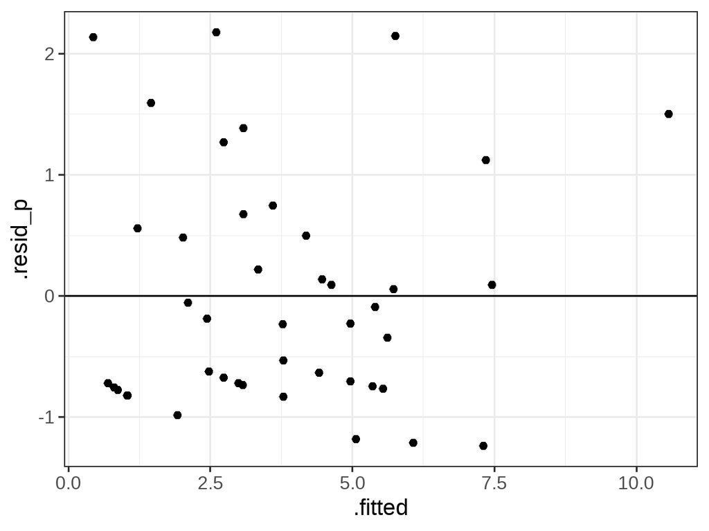

```r
M_nb_diag <- data.frame(.fitted = fitted(M_nb, type = "response"),
                          .resid_p = residuals(M_nb, type = "pearson"),
                          pol)
gg_resid <- ggplot(M_nb_diag, aes(y = .resid_p)) + geom_hline(yintercept = 0)
gg_resid + geom_point(aes(x = .fitted))
```

Ничего необычного (нет отрицательных предсказаний, нет заметной нелинейности).

## Проверка на сверхдисперсию

Обратите внимание, у моделей с отрицательным биномиальным распределением добавляется еще один параметр

```r
overdisp_fun(M_nb)
```

```
  chisq   ratio     rdf       p
38.9817  1.0828 36.0000  0.3371
```

Избыточности дисперсии нет

## Графики остатков от переменных, которые есть в модели

```r
plot_grid(gg_resid + geom_boxplot(aes(x = Treatment)),
          gg_resid + geom_boxplot(aes(x = as.factor(Hours))),
          gg_resid + geom_point(aes(x = DiversityD_1)),
          gg_resid + geom_point(aes(x = Flowers)),
          nrow = 2)
```

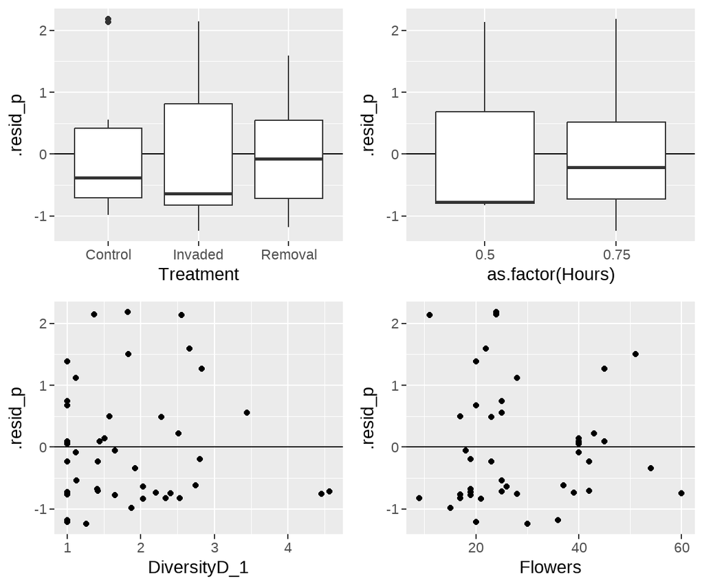

Ничего страшного. Может показаться, что есть какой-то невнятный нелинейный паттерн на графике зависимости отстатков от количества цветков мускари, но скорее всего это связано с небольшим количеством наблюдений.

## Графики остатков от переменных, которых нет в модели

Из всех оставшихся переменных только `Total_1` можно рассматривать как потенциальный предиктор.

```r
gg_resid + geom_point(aes(x = Total_1))
```

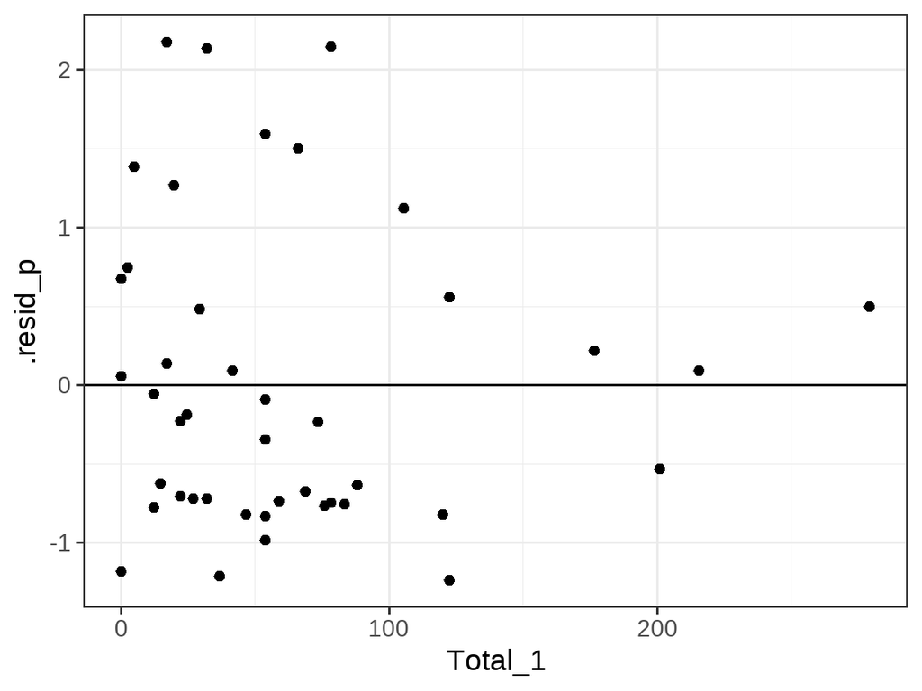

Ничего криминального. Никаких паттернов. Можно не включать в модель.

## Данные для предсказаний

```r
NewData <- pol %>% group_by(Treatment)%>%
  do(data.frame(Flowers = seq(min(.$Flowers), max(.$Flowers), length.out=50))) %>%
  mutate(DiversityD_1 = mean(pol$DiversityD_1),
         Hours = 0.75)
```

Как и в прошлый раз, давайте получим предсказания при помощи операций с матрицами, чтобы своими глазами увидеть работу функции связи.

Осторожно!  
Хоть и можно получить предсказания при помощи `predict()`, но  
**`predict()` возвращает “правильные” `SE` только в масштабе функции связи!**

```r
?predict.glm
```

## Предсказания модели при помощи операций с матрицами

```r
# Модельная матрица и коэффициенты
X <- model.matrix(~ Treatment + DiversityD_1 + Flowers + Hours, data = NewData)
betas <- coef(M_nb)

# Предсказанные значения и стандартные ошибки...
# ...в масштабе функции связи (логарифм)
NewData$fit_eta <- X %*% betas
NewData$SE_eta <- sqrt(diag(X %*% vcov(M_nb) %*% t(X)))

# ...в масштабе отклика (применяем функцию, обратную функции связи)
NewData$fit_mu <- exp(NewData$fit_eta)
NewData$lwr <- exp(NewData$fit_eta - 2 * NewData$SE_eta)
NewData$upr <- exp(NewData$fit_eta + 2 * NewData$SE_eta)

head(NewData, 2)
```

```
# A tibble: 2 × 9
# Groups:   Treatment [1]
  Treatment Flowers DiversityD_1 Hours fit_eta[,1] SE_eta fit_mu[,1] lwr[,1] upr[,1]
  <chr>       <dbl>        <dbl> <dbl>       <dbl>  <dbl>      <dbl>   <dbl>   <dbl>
1 Control      11           1.86  0.75       0.538  0.357       1.71   0.839    3.49
2 Control      11.7         1.86  0.75       0.560  0.351       1.75   0.867    3.53
```

## График предсказаний в масштабе функции связи

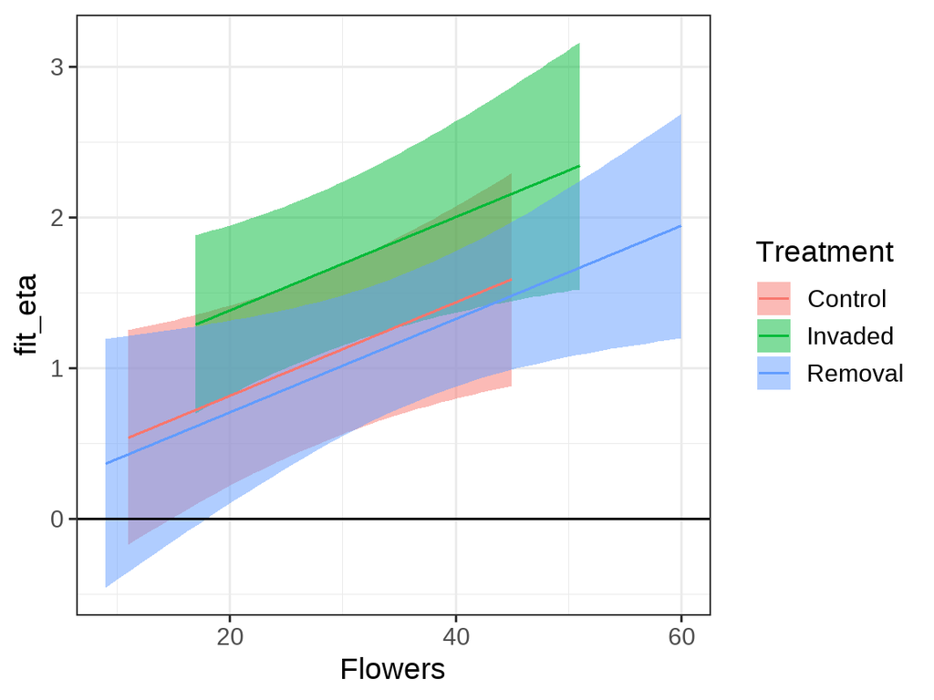

```r
ggplot(NewData, aes(x = Flowers, y = fit_eta, fill = Treatment)) +
  geom_ribbon(aes(ymin = fit_eta - 2 * SE_eta,
                  ymax = fit_eta + 2 * SE_eta),
              alpha = 0.5) +
  geom_line(aes(colour = Treatment)) +
  geom_hline(yintercept = 0)
```

В масштабе функции связи мы моделируем линейную зависимость логарифмов мат. ожидания отклика от предикторов.

## График предсказаний в масштабе отклика

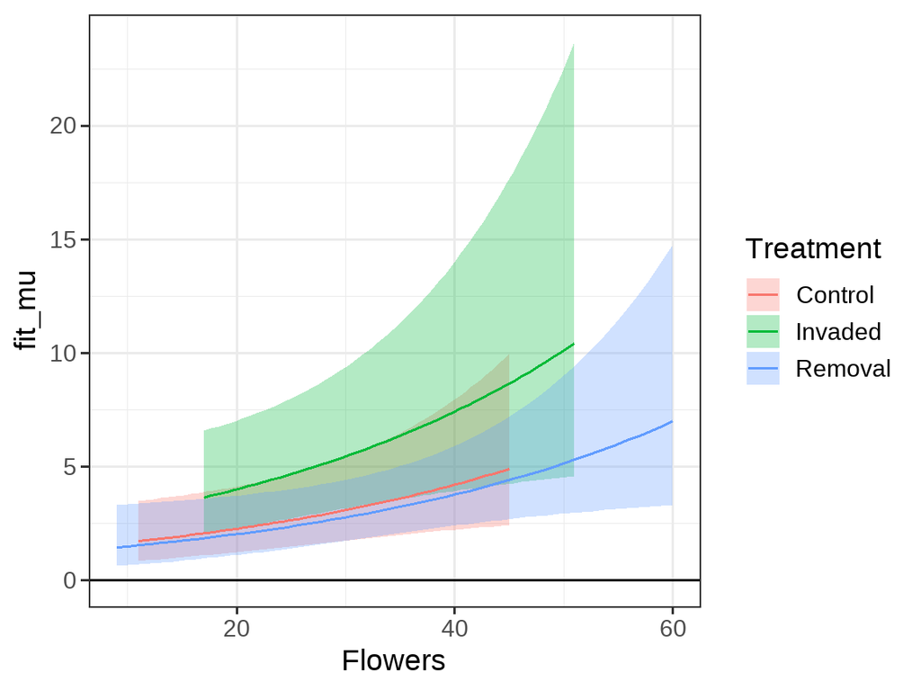

```r
ggplot(NewData, aes(x = Flowers, y = fit_mu, fill = Treatment)) +
  geom_ribbon(aes(ymin = lwr,
                  ymax = upr),
              alpha = 0.3) +
  geom_line(aes(colour = Treatment)) +
  geom_hline(yintercept = 0)
```

GLM с отрицательным биномиальным распределением отклика моделирует его нелинейную связь предикторами за счет функции связи $log()$.

## GLM с отрицательным биномиальным распределением отклика

GLM с отрицательным биномиальным распределением отклика до какой-то степени может учесть гетерогенность дисперсии ( $E(y_i) = \mu_i$, $var(y_i) = \mu_i + \frac{\mu_i^2}{k}$).

На графике видно, что стандартные ошибки возрастают с увеличением предсказанного значения даже сильнее, чем это было у Пуассоновской модели.

Этого оказалось вполне достаточно для моделирования данных (сверхдисперсии здесь нет).

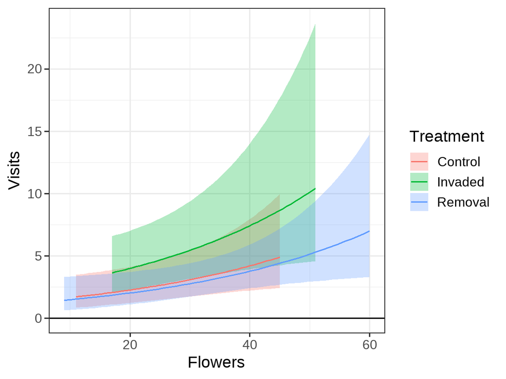

## Выводы

Число визитов опылителей на цветки мускари значимо зависит от разнообразия флоры на данном участке (тест отношения правдоподобий, $p = 0.02$).

При этом, чем больше цветов самого мускари, тем больше прилетает опылителей (тест отношения правдоподобий, $p = 0.01$).

Влияние присутствия вида-вселенца или его цветов не было выявлено.

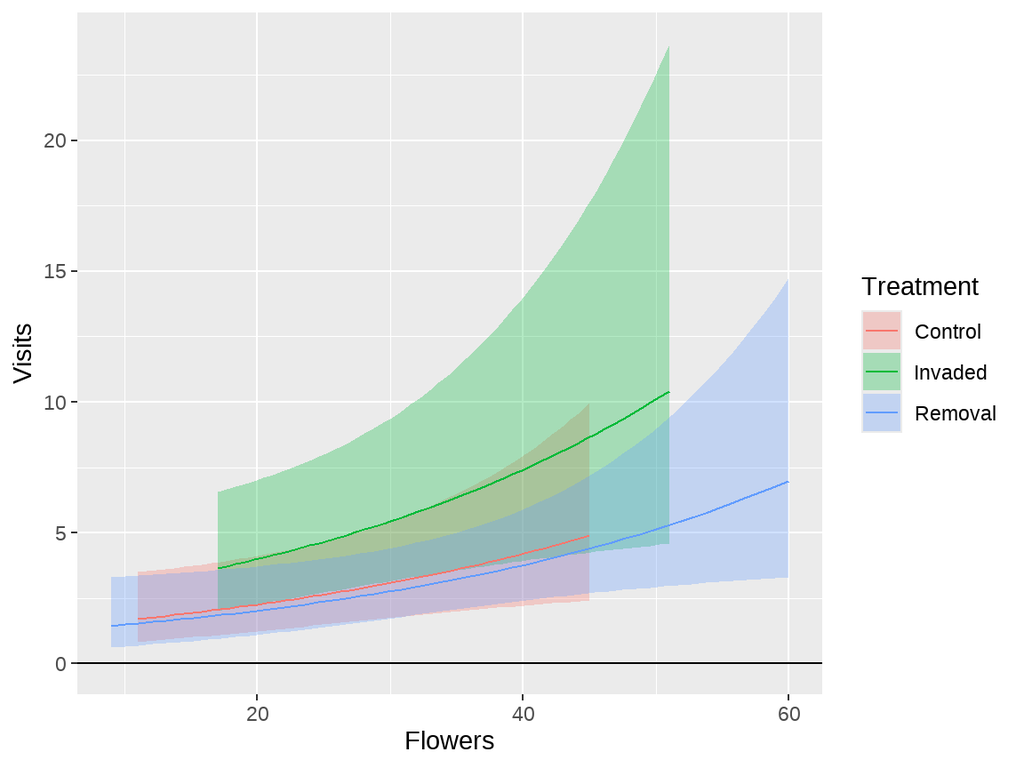

## Take-home messages

- Важно формулировать модель с учетом распределения зависимой переменной. При моделировании счетных данных используются:
  - распределение Пуассона,
  - отрицательное биномиальное распределение.
- В моделях для счетных данных не должно быть избыточности дисперсии. Она может возникать по многим причинам, поэтому нет единого рецепта борьбы с ней:
  - В квази-пуассоновских GLM используются поправки для стандартных ошибок оценок коэффициентов модели.
  - В моделях, основанных на отрицательном биномиальном распределении, специальный параметр этого распределения “описывает” сверхдисперсию.

## Что почитать

- Zuur, A.F. and Ieno, E.N., 2016. A protocol for conducting and presenting results of regression-type analyses. Methods in Ecology and Evolution, 7(6), pp.636-645.
- Кабаков Р.И. R в действии. Анализ и визуализация данных на языке R. М.: ДМК Пресс, 2014
- Zuur, A., Ieno, E.N. and Smith, G.M., 2007. Analyzing ecological data. Springer Science & Business Media.